# Juvenile Snowshoe Hares Exploratory Report

Annie Lovell

11/16/2020

1. Overview

The U.S. Long Term Ecological Research Network is a group of scientists and students studying ecological processes in a diversity of ecosystems across the U.S. The project was established by the National Science Foundation in 1980. Within the network, the Bonanza Creek Long Term Ecological Research (LTER) program is studying the interactive impacts of climate change and disturbances within the Alaskan boreal forest, which is part of one of the largest forested biomes on Earth. The Bonanza Riparian is a site where researchers are live-trapping snowshoe hares to monitor abundance and survival. (Kielland, et al. 2017)

This report provides an exploratory overview of the differences in juvenile snowshoe hares at the the Bonanza Creek LTER (Kielland, et al. 2017). Specifically, this report will explore: 1) The total number of juvenile hares trapped each year 2) Compare juvenile hare weights by sex and site 3) Explore the relationship between juvenile snowshoe hares hind foot length and weight

2. Data and Methods

Snowshoe hare sex, weight and hind foot length measurements were collected and made available by Knut Kielland and colleagues at the Bonanza Creek Experimental Forest site, outside of Fairbanks, Alaska. The data contain observations of snowshoe hares, collected between 1998 and 2012. First, exploratory data investigation and visualization will be conducted for juvenile hares trapped each year. Next, hare weights by sex will be compared by a two-sample t-tests using a significance level ($\alpha$) of 0.05 throughout. Differences between groups are described by Cohen’s *d* effect size. Next, the relationship between juvenile hare weight and hind foot length will then be explored by simple linear regression. All analyses are in R version 4.0.2 using RSTudio version 1.3.1056.

3. Exploratory Findings
1. Annual Juvenile Hare Trap Counts

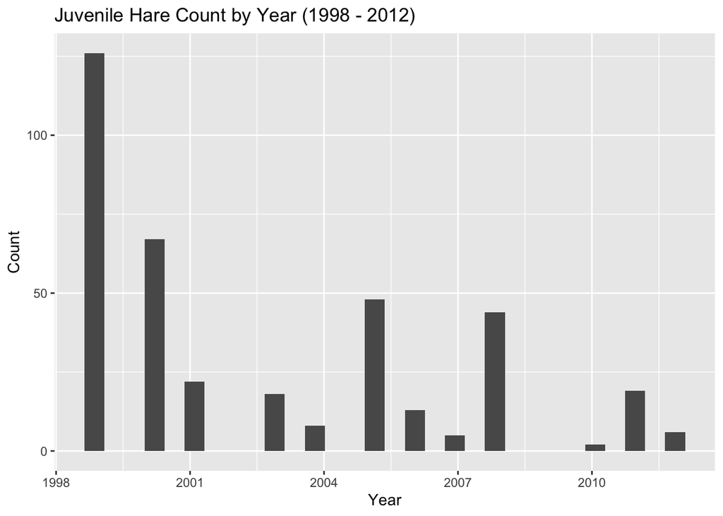

Figure 1. Histogram showing total juvenile hare count by year from 1998 to 2012 for all grid sites within the Bonanza Creek ITER.

In order to better standardize data on juvenile hare population for future analysis, it would be important to record the number of days and number of traps used each year, so the data for hare counts could be analyzed with regard to days that trappings were attempted and the number of traps used annually.

2. Relationship between Juvenile Hare Weights by Sex and Grid Site

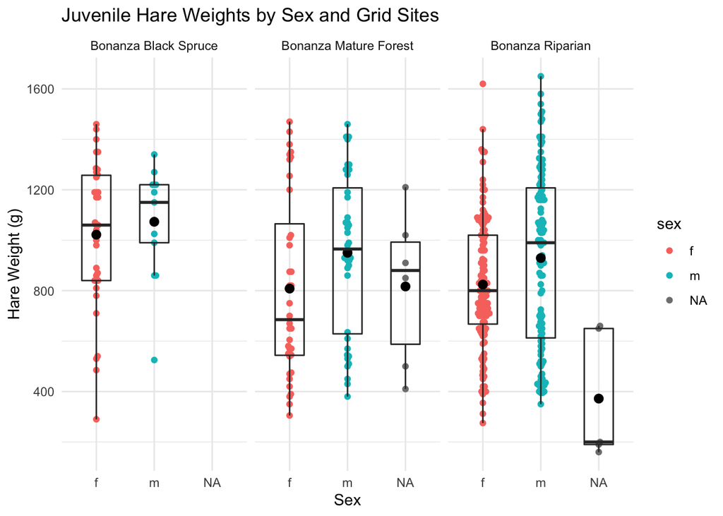

Figure 2. Juvenile hare weights by sex and grid sites.

Figure 2 shows juvenile hare weights (in grams) by sex and grid sites (Riparian, Mature Forest, and Black Spruce). The colors coral (female), teal (male) and gray (groups with no recorded trappings) points indicate individual observations for weight. This visualization includes a beeswarm plot overlaid by a boxplot. The box endpoints indicate the 25th and 75th percentile values; the black line and black point within the box indicate the median and mean value for each species, respectively.

Distributions of weight for both genders in all three grid sites were relatively normal and symmetric.. The greatest number of observations were female hares trapped at the Bonanza Riparian grid site. The Black Spruce grid site has the highest mean and median weights for both sexes. There are no missing weight observations at the Black Spruce grid site (with the exception of one observation that is missing both weight and sex, not included in this graph). Females and males in the Bonanza Mature Forest and Bonanza Riparian Forest have similar mean weights. The missing weights for hares without a gender assignment are smaller than the mean and median weights at the Bonanza Riparian grid site. This might indicate that these individuals were too small to sex. (Figure 2)

3. Comparison of Juvenile Weights (in grams) by Gender

Table 1. Distributions of weight (in grams) for males and females snowshoe hares.

| Sex | Mean Weight (g) | Standard Deviation | Sample Size |
| --- | --- | --- | --- |
| f | 855.39 | 292.25 | 200 |
| m | 945.86 | 333.22 | 163 |

4. Relationship Between Juvenile Weight and Hind Foot Length

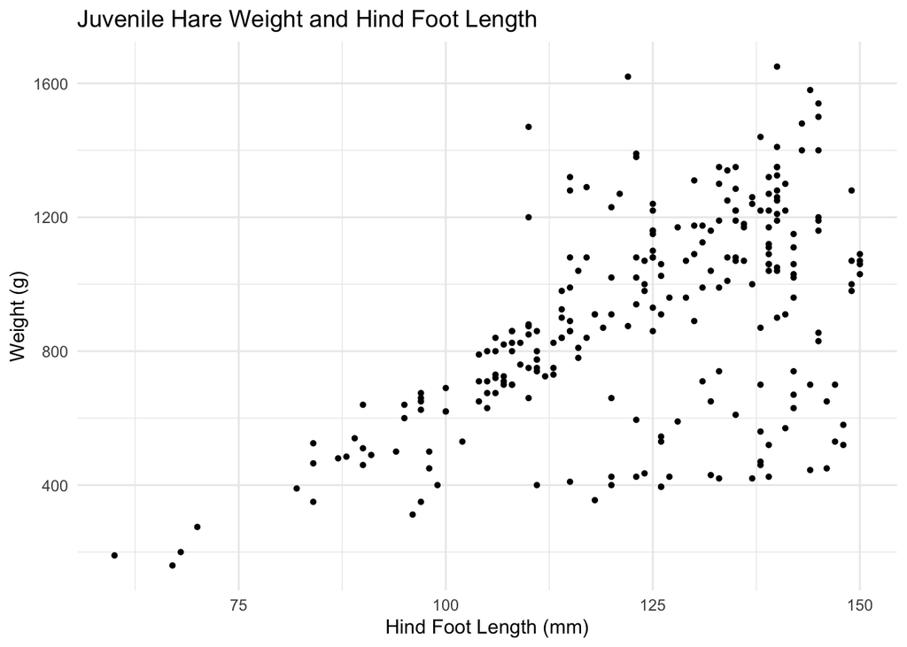

Figure 3. Relationship between juvenile snowshoe hare weight (g) and hind foot length (mm) for all trappings (includes both male and female at all grid sites).

Linear model summary: $\beta$<sub>1</sub> = 9.52 g mm<sup>-1</sup>, p < 0.001, R<sup>2</sup> = 0.3, Pearson’s *r* = 0.55). Data: Kielland et al. (2017).

Summary

Exploratory data analysis reveals the following initial findings.

Next steps:

For further analysis, it may be interesting to compare hind foot length for males and females at each of the different grid sites (similar to the analysis done in Task 2 exploring the relationship between sex and weight at each grid site). If hind foot was larger at the Bonanza Black Spruce grid site, it would be ineresting to do further analysis to hypothesize potential reasons the juvenile hares at this site specifically weigh more and have longer hind foot measurements.

Citations

Kielland, K., F.S. Chapin, R.W. Ruess, and Bonanza Creek LTER. 2017. Snowshoe hare physical data in Bonanza Creek Experimental Forest: 1999-Present ver 22. Environmental Data Initiative. [Link](https://doi.org/10.6073/pasta/03dce4856d79b91557d8e6ce2cbcdc14)

Metadata: [Link](https://portal.edirepository.org/nis/metadataviewer?packageid=knb-lter-bnz.55.22)